# mylo_churn_prediction

## Project Objective:

```
Build a predictive model to estimate user activity two weeks in advance based on behavioral data (e.g., total answers, new contacts, active days), with the goal of identifying users at risk of churn and improving retention strategies.
```

## Requirements

```python
# [project]
# name = "mylo-ai"
# version = "0.1.0"
# description = "Mylo AI - Churn Prediction"
# readme = "README.md"
# requires-python = ">=3.13"
# dependencies = [
#     "bokeh>=3.7.2",
#     "fastparquet>=2024.11.0",
#     "ipykernel>=6.29.5",
#     "jupyter>=1.1.1",
#     "jupyter-bokeh>=4.0.5",
#     "jupyterlab>=4.4.0",
#     "lightgbm>=4.6.0",
#     "matplotlib>=3.10.1",
#     "matplotlib-inline>=0.1.7",
#     "numpy>=2.2.5",
#     "openpyxl>=3.1.5",
#     "pandas>=2.2.3",
#     "pyarrow>=19.0.1",
#     "scikit-learn>=1.6.1",
#     "shap>=0.47.2",
# ]
```

## Imports

```python
import time
from datetime import datetime, timedelta
from itertools import product
from pathlib import Path
from typing import List

import lightgbm as lgb
import matplotlib.pyplot as plt
import numpy as np
from scipy.stats import percentileofscore
import pandas as pd
import seaborn as sns
import shap
from bokeh.layouts import gridplot
from bokeh.models import ColorBar, LinearColorMapper, BasicTicker, ColumnDataSource
from bokeh.palettes import Spectral10
from bokeh.plotting import figure, output_notebook, show
from bokeh.transform import factor_cmap, linear_cmap
from sklearn.inspection import PartialDependenceDisplay
from sklearn.metrics import (
    mean_squared_error,
    mean_absolute_error,
    r2_score,
    roc_curve,
    auc,
    f1_score,
)
from sklearn.model_selection import StratifiedKFold, train_test_split

output_notebook()

# Set paths:
data_path = Path("/home/vadim/Projects/Mylo_AI/data/")
results_path = Path("/home/vadim/Projects/Mylo_AI/results/")
# source .venv/bin/activate
```

Loading BokehJS ...

### XLSX to Parquet Conversion. Executed once

Fix automatic type conversion issues.

Speed up reading and writing operations by a factor of 300+.

```python
def clean_and_convert_types(df: pd.DataFrame) -> pd.DataFrame:
    """
    Cleans the dataframe by:
    - Replacing 'NULL' and '#VALUE!' with None
    - Converting datetime-like strings to datetime using '%d/%m/%Y %H:%M' only when conversion is likely,
      excluding specific columns explicitly
    - Converting all remaining object-type columns to string to fix mixed types

    Args:
        df (pd.DataFrame): Input DataFrame

    Returns:
        pd.DataFrame: Cleaned DataFrame
    """
    # Replace invalid markers
    df = df.replace({"NULL": None, "#VALUE!": None})

    # Manually converted columns (case-sensitive as per DataFrame column names)
    convert_to_str = {  # patch
        "ProfileStatusText",
        "AppVersion",
        "DeleteReason",
        "DeviceId",
    }
    convert_to_int = {  # patch
        "UserIdMin",
        "UserIdMin",
    }

    for col in df.select_dtypes(include="object").columns:
        if col in convert_to_str:
            df[col] = df[col].astype(str)
            continue

        if col in convert_to_int:
            df[col] = df[col].astype(int)
            continue

        # Sample to test if the column is likely datetime
        sample = (
            df[col]
            .dropna()
            .astype(str)
            .sample(n=min(100, len(df[col].dropna())), random_state=42)
        )
        parsed = pd.to_datetime(sample, format="%d/%m/%Y %H:%M", errors="coerce")
        success_rate = parsed.notnull().mean()

        if success_rate >= 0.8:
            df[col] = pd.to_datetime(df[col], format="%d/%m/%Y %H:%M", errors="coerce")
        else:
            df[col] = df[col].astype(str)

    return df
```

```python
if False:  # executed only once
    # ================================
    # Read XLSX Data
    # ================================
    start = time.time()
    df_activity = pd.read_excel(data_path / "Activity.xlsx")
    df_messages = pd.read_excel(data_path / "Messages.xlsx")
    df_sessions = pd.read_excel(data_path / "Sessions.xlsx")
    df_users = pd.read_excel(data_path / "Users.xlsx")
    print(f"✅ All XLSX files read in {round(time.time() - start, 2)} seconds!")

    # ================================
    # Clean and convert types
    # ================================
    df_activity = clean_and_convert_types(df_activity)
    df_messages = clean_and_convert_types(df_messages)
    df_sessions = clean_and_convert_types(df_sessions)
    df_users = clean_and_convert_types(df_users)

    # ================================
    # Export to parquet for fast read/write
    # ================================
    df_activity.to_parquet(data_path / "Activity.pqt", index=False)
    df_messages.to_parquet(data_path / "Messages.pqt", index=False)
    df_sessions.to_parquet(data_path / "Sessions.pqt", index=False)
    df_users.to_parquet(data_path / "Users.pqt", index=False)
    print("✅ All files exported to Parquet format successfully!")

    # ✅ All XLSX files read in ~60 sec
```

## Load Data

```python
# ================================
# Read Parquet Data
# ================================
start = time.time()
df_activity = pd.read_parquet(data_path / "Activity.pqt")
df_messages = pd.read_parquet(data_path / "Messages.pqt")
df_sessions = pd.read_parquet(data_path / "Sessions.pqt")
df_users = pd.read_parquet(data_path / "Users.pqt")
print(f"✅ All Parquet files read in {round(time.time() - start, 2)} seconds!")
```

```
✅ All Parquet files read in 0.06 seconds!
```

## EDA: Exploratory Data Analysis

Explore data sets types and missing values. Plot histograms and correlation matrix of numerical columns.

Fix automatic type conversion issues.

```python
def is_identifier_or_datetime(colname: str) -> bool:
    col_lower = colname.lower()
    return (
        col_lower == "id"
        or colname.endswith("Id")
        or colname.endswith("ID")
        or "date" in col_lower
        or "time" in col_lower
    )


def interactive_eda(df: pd.DataFrame) -> None:
    """
    Perform a fully Bokeh-based interactive EDA on the provided DataFrame,
    excluding datetime, identifier, and 100% missing columns from plots/statistics.
    """
    print("★ DataFrame Shape:", df.shape)
    print("★ Columns:", list(df.columns))
    print("★ Data Types:")
    print(df.dtypes)

    # --- Describe Statistics ---
    display(df.describe(include="all"))

    # --- Missing Values ---
    print("\n★ Missing Values:")
    missing_count = df.isnull().sum()
    missing_percent = (missing_count / len(df)) * 100
    missing_summary = pd.DataFrame(
        {"Missing Count": missing_count, "Missing %": missing_percent.round(2)}
    )
    display(
        missing_summary[missing_summary["Missing Count"] > 0].sort_values(
            "Missing %", ascending=False
        )
    )

    # --- Remove columns with 100% missing values ---
    df = df.loc[:, df.notnull().any()]

    # --- Select Clean Numerical Features ---
    numerical_features = [
        col
        for col in df.select_dtypes(include=["int64", "float64"]).columns
        if not is_identifier_or_datetime(col)
    ]

    # --- Distribution Histograms ---
    if numerical_features:
        histograms = []
        for col in numerical_features:
            hist, edges = np.histogram(df[col].dropna(), bins=30)
            p = figure(
                title=f"Distribution of {col}",
                background_fill_color="#fafafa",
                width=400,
                height=300,
            )
            p.quad(
                top=hist,
                bottom=0,
                left=edges[:-1],
                right=edges[1:],
                fill_color="navy",
                line_color="white",
                alpha=0.7,
            )
            p.xaxis.axis_label = col
            p.yaxis.axis_label = "Frequency"
            histograms.append(p)
        show(gridplot(histograms, ncols=2))
    else:
        print("\n★ No suitable numerical features for histograms.")

    # --- Boxplots ---
    if numerical_features:
        boxplots = []
        for col in numerical_features:
            q1, q2, q3 = df[col].quantile([0.25, 0.5, 0.75])
            iqr = q3 - q1
            lower = q1 - 1.5 * iqr
            upper = q3 + 1.5 * iqr
            source = ColumnDataSource(
                data=dict(
                    x=[col], q1=[q1], q2=[q2], q3=[q3], lower=[lower], upper=[upper]
                )
            )
            p = figure(title=f"Boxplot of {col}", width=400, height=300, x_range=[col])
            p.vbar(
                x="x",
                width=0.7,
                top="q3",
                bottom="q2",
                source=source,
                fill_color="#E08E79",
            )
            p.vbar(
                x="x",
                width=0.7,
                top="q2",
                bottom="q1",
                source=source,
                fill_color="#3B8686",
            )
            p.segment("x", "upper", "x", "q3", source=source)
            p.segment("x", "lower", "x", "q1", source=source)
            boxplots.append(p)
        show(gridplot(boxplots, ncols=2))
    else:
        print("\n★ No suitable numerical features for boxplots.")

    # --- Categorical Distributions ---
    categorical_features = df.select_dtypes(include=["object"]).columns.tolist()
    categorical_features = [
        col for col in categorical_features if df[col].notnull().sum() > 0
    ]
    if categorical_features:
        barplots = []
        for col in categorical_features:
            top_categories = df[col].value_counts(normalize=True).head(10)
            category_labels = top_categories.index.astype(
                str
            ).tolist()  # ✅ Convert to string
            source = ColumnDataSource(
                data=dict(
                    categories=category_labels,
                    counts=top_categories.values.tolist(),
                )
            )
            p = figure(
                x_range=category_labels,
                title=f"Top categories in {col}",
                width=400,
                height=300,
            )
            p.vbar(
                x="categories",
                top="counts",
                width=0.9,
                source=source,
                line_color="white",
                fill_color=factor_cmap(
                    "categories",
                    palette=Spectral10,
                    factors=category_labels,
                ),
            )
            p.xaxis.major_label_orientation = 1
            p.xaxis.axis_label = col
            p.yaxis.axis_label = "Proportion"
            barplots.append(p)
        show(gridplot(barplots, ncols=2))
    else:
        print("\n★ No categorical features for barplots.")

    # --- Correlation Heatmap ---
    if len(numerical_features) >= 2:
        corr = df[numerical_features].corr().stack().reset_index()
        corr.columns = ["Feature1", "Feature2", "Correlation"]
        corr = corr[corr["Feature1"] != corr["Feature2"]]
        source = ColumnDataSource(corr)
        mapper = LinearColorMapper(palette=Spectral10, low=-1.0, high=1.0)
        p = figure(
            x_range=numerical_features,
            y_range=numerical_features,
            width=800,
            height=800,
            title="Correlation Heatmap with ColorBar",
            toolbar_location=None,
            tools="",
        )
        p.rect(
            x="Feature1",
            y="Feature2",
            width=1,
            height=1,
            source=source,
            line_color=None,
            fill_alpha=0.8,
            fill_color={"field": "Correlation", "transform": mapper},
        )
        color_bar = ColorBar(
            color_mapper=mapper,
            ticker=BasicTicker(desired_num_ticks=len(Spectral10)),
            label_standoff=12,
            border_line_color=None,
            location=(0, 0),
        )
        p.add_layout(color_bar, "right")
        show(p)
    else:
        print("\n★ Not enough numerical features for correlation heatmap.")
```

### EDA for Activity Data

```python
interactive_eda(df_activity)
```

```
★ DataFrame Shape: (34198, 2)
★ Columns: ['Date', 'UserId']
★ Data Types:
Date      datetime64[ns]
UserId             int64
dtype: object
```

|  | Date | UserId |
| --- | --- | --- |
| count | 34198 | 34198.000000 |
| mean | 2025-02-07 11:43:52.364465664 | 259948.458974 |
| min | 2025-01-01 00:00:00 | 256887.000000 |
| 25% | 2025-01-11 00:00:00 | 258469.000000 |
| 50% | 2025-01-30 00:00:00 | 259883.000000 |
| 75% | 2025-03-02 00:00:00 | 261479.000000 |
| max | 2025-04-22 00:00:00 | 262985.000000 |
| std | NaN | 1743.736989 |

```
★ Missing Values:
```

|  | Missing Count | Missing % |
| --- | --- | --- |

```
★ No suitable numerical features for histograms.

★ No suitable numerical features for boxplots.

★ No categorical features for barplots.

★ Not enough numerical features for correlation heatmap.
```

### EDA for Messages Data

```python
interactive_eda(df_messages)
```

```
★ DataFrame Shape: (506433, 7)
★ Columns: ['id', 'UserId', 'SessionId', 'type', 'QuestionId', 'AnswerId', 'CreatedAt']
★ Data Types:
id                     int64
UserId                 int64
SessionId              int64
type                   int64
QuestionId           float64
AnswerId             float64
CreatedAt     datetime64[ns]
dtype: object
```

|  | id | UserId | SessionId | type | QuestionId | AnswerId | CreatedAt |
| --- | --- | --- | --- | --- | --- | --- | --- |
| count | 5.064330e+05 | 506433.000000 | 5.064330e+05 | 506433.000000 | 308265.000000 | 167523.000000 | 506433 |
| mean | 1.741545e+07 | 259970.713376 | 4.614211e+06 | 2.269536 | 5817.611036 | 3325.111997 | 2025-01-29 07:44:19.555977984 |
| min | 1.189556e+07 | 256887.000000 | 3.299036e+06 | 1.000000 | 500.000000 | 2544.000000 | 2025-01-01 00:52:28.349000 |
| 25% | 1.279860e+07 | 258407.000000 | 3.517916e+06 | 1.000000 | 5630.000000 | 2941.000000 | 2025-01-05 21:01:58.545999872 |
| 50% | 1.432990e+07 | 259897.000000 | 3.919349e+06 | 3.000000 | 5780.000000 | 3309.000000 | 2025-01-15 22:10:01.961999872 |
| 75% | 2.008187e+07 | 261645.000000 | 5.175563e+06 | 3.000000 | 5955.000000 | 3639.000000 | 2025-02-16 16:28:31.019000064 |
| max | 3.590043e+07 | 262985.000000 | 9.338693e+06 | 6.000000 | 7587.000000 | 6721.000000 | 2025-04-22 08:01:11.526000 |
| std | 6.453370e+06 | 1802.843596 | 1.523349e+06 | 1.041043 | 287.309679 | 562.740665 | NaN |

```
★ Missing Values:
```

|  | Missing Count | Missing % |
| --- | --- | --- |
| AnswerId | 338910 | 66.92 |
| QuestionId | 198168 | 39.13 |

```
★ No categorical features for barplots.

★ Not enough numerical features for correlation heatmap.
```

### EDA for Sessions Data

```python
interactive_eda(df_sessions)
```

```
★ DataFrame Shape: (157281, 21)
★ Columns: ['Id', 'State', 'CompleteAt', 'CreatedAt', 'UpdatedAt', 'Status', 'LanguageId', 'FlowState', 'SessionOrigin', 'UserIdMin', 'UserIdMax', 'SessionMessageCount', 'FirstResponderId', 'AnswerCountUserMin', 'AnswerCountUserMax', 'LastQuestionTimeForUserMin', 'LastQuestionTimeForUserMax', 'LastA…
★ Data Types:
Id                                     int64
State                                  int64
CompleteAt                           float64
CreatedAt                     datetime64[ns]
UpdatedAt                     datetime64[ns]
Status                                 int64
LanguageId                             int64
FlowState                             object
SessionOrigin                          int64
UserIdMin                            float64
UserIdMax                            float64
SessionMessageCount                    int64
FirstResponderId                     float64
AnswerCountUserMin                   float64
AnswerCountUserMax                   float64
LastQuestionTimeForUserMin    datetime64[ns]
LastQuestionTimeForUserMax    datetime64[ns]
LastAccessUserMin             datetime64[ns]
LastAccessUserMax             datetime64[ns]
LastMessageTime               datetime64[ns]
QuestionsLimit                       float64
dtype: object
```

|  | Id | State | CompleteAt | CreatedAt | UpdatedAt | Status | LanguageId | FlowState | SessionOrigin | UserIdMin | ... | SessionMessageCount | FirstResponderId | AnswerCountUserMin | AnswerCountUserMax | LastQuestionTimeForUserMin | LastQuestionTimeForUserMax | LastAccessUserMin | LastAccessUserMax | LastMessageTime | QuestionsLimit |
| --- | --- | --- | --- | --- | --- | --- | --- | --- | --- | --- | --- | --- | --- | --- | --- | --- | --- | --- | --- | --- | --- |
| count | 1.572810e+05 | 157281.000000 | 0.0 | 157281 | 157281 | 157281.000000 | 157281.000000 | 157281 | 157281.000000 | 152167.000000 | ... | 157281.000000 | 23731.000000 | 157113.000000 | 157113.000000 | 69993 | 87569 | 123506 | 118182 | 156742 | 152167.000000 |
| unique | NaN | NaN | NaN | NaN | NaN | NaN | NaN | 9 | NaN | NaN | ... | NaN | NaN | NaN | NaN | NaN | NaN | NaN | NaN | NaN | NaN |
| top | NaN | NaN | NaN | NaN | NaN | NaN | NaN | Question_user_answer | NaN | NaN | ... | NaN | NaN | NaN | NaN | NaN | NaN | NaN | NaN | NaN | NaN |
| freq | NaN | NaN | NaN | NaN | NaN | NaN | NaN | 129438 | NaN | NaN | ... | NaN | NaN | NaN | NaN | NaN | NaN | NaN | NaN | NaN | NaN |
| mean | 4.639528e+06 | 4.710594 | NaN | 2025-01-27 22:06:58.097358592 | 2025-02-03 00:13:05.038774784 | 0.762756 | 1.001545 | NaN | 2.573547 | 233724.958375 | ... | 12.167725 | 276839.181703 | 1.891912 | 1.775582 | 2025-02-04 12:13:14.607353088 | 2025-02-01 04:10:29.955328256 | 2025-02-01 09:13:39.783132672 | 2025-02-01 12:23:33.008356352 | 2025-01-30 08:23:12.698851584 | 4.979943 |
| min | 3.299036e+06 | 1.000000 | NaN | 2025-01-01 00:51:22.885000 | 2025-01-01 00:58:14.081000 | -1.000000 | 1.000000 | NaN | 0.000000 | 159635.000000 | ... | 0.000000 | 159645.000000 | 0.000000 | 0.000000 | 2025-01-01 00:54:51.674000 | 2025-01-01 00:54:51.674000 | 2025-01-01 01:23:32.687000 | 2025-01-01 01:06:10.260000 | 2025-01-01 00:54:51.674000 | 3.000000 |
| 25% | 3.538733e+06 | 4.000000 | NaN | 2025-01-05 18:25:46.375000064 | 2025-01-07 10:08:24.603000064 | 1.000000 | 1.000000 | NaN | 0.000000 | 209345.000000 | ... | 4.000000 | 258449.000000 | 0.000000 | 0.000000 | 2025-01-06 12:58:43.176999936 | 2025-01-06 09:25:11.344999936 | 2025-01-07 09:30:16.481749760 | 2025-01-06 20:34:11.797499904 | 2025-01-06 11:23:40.940999936 | 5.000000 |
| 50% | 3.925151e+06 | 4.000000 | NaN | 2025-01-13 20:29:47.550000128 | 2025-01-20 19:15:28.887000064 | 1.000000 | 1.000000 | NaN | 0.000000 | 250407.000000 | ... | 7.000000 | 261401.000000 | 1.000000 | 1.000000 | 2025-01-19 18:33:19.896000 | 2025-01-16 16:45:47.907000064 | 2025-01-20 09:03:18.656999936 | 2025-01-19 21:46:02.466500096 | 2025-01-16 20:55:51.238000128 | 5.000000 |
| 75% | 5.068514e+06 | 6.000000 | NaN | 2025-02-13 21:45:42.940000 | 2025-02-22 22:40:19.716000 | 1.000000 | 1.000000 | NaN | 0.000000 | 259431.000000 | ... | 16.000000 | 304695.000000 | 3.000000 | 3.000000 | 2025-02-27 17:05:56.470000128 | 2025-02-19 00:30:02.167000064 | 2025-02-17 16:10:30.034500096 | 2025-02-18 17:48:55.888999936 | 2025-02-16 21:19:26.120749824 | 5.000000 |
| max | 9.338732e+06 | 7.000000 | NaN | 2025-04-22 07:51:50.447000 | 2025-04-22 07:53:14.489000 | 1.000000 | 2.000000 | NaN | 30.000000 | 262981.000000 | ... | 1780.000000 | 411295.000000 | 17.000000 | 11.000000 | 2025-04-22 07:53:33.530000 | 2025-04-22 07:53:33.530000 | 2025-04-22 07:53:38.360000 | 2025-04-22 07:53:04.830000 | 2025-04-22 07:53:33.537000 | 5.000000 |
| std | 1.566101e+06 | 1.349463 | NaN | NaN | NaN | 0.646689 | 0.039276 | NaN | 7.987865 | 31598.262310 | ... | 20.054815 | 47164.989433 | 1.772282 | 1.788093 | NaN | NaN | NaN | NaN | NaN | 0.199278 |

11 rows × 21 columns

```
★ Missing Values:
```

|  | Missing Count | Missing % |
| --- | --- | --- |
| CompleteAt | 157281 | 100.00 |
| FirstResponderId | 133550 | 84.91 |
| LastQuestionTimeForUserMin | 87288 | 55.50 |
| LastQuestionTimeForUserMax | 69712 | 44.32 |
| LastAccessUserMax | 39099 | 24.86 |
| LastAccessUserMin | 33775 | 21.47 |
| UserIdMax | 5114 | 3.25 |
| UserIdMin | 5114 | 3.25 |
| QuestionsLimit | 5114 | 3.25 |
| LastMessageTime | 539 | 0.34 |
| AnswerCountUserMin | 168 | 0.11 |
| AnswerCountUserMax | 168 | 0.11 |

### EDA for Users Data

```python
interactive_eda(df_users)
```

```
★ DataFrame Shape: (3050, 34)
★ Columns: ['UserId', 'BirthDate', 'LanguageId', 'CountryId', 'UpdatedAt', 'CreatedAt', 'Status', 'BotLanguageId', 'Test', 'RegistrationComplete', 'AllowNotificaions', 'NotificaionsPrioritization', 'SendNotificaionsDailyReminders', 'SendNotificaionsInactivityReminders', 'SendNotificaionsSpecialOffer…
★ Data Types:
UserId                                          int64
BirthDate                              datetime64[ns]
LanguageId                                      int64
CountryId                                       int64
UpdatedAt                              datetime64[ns]
CreatedAt                              datetime64[ns]
Status                                          int64
BotLanguageId                                   int64
Test                                            int64
RegistrationComplete                            int64
AllowNotificaions                               int64
NotificaionsPrioritization                      int64
SendNotificaionsDailyReminders                  int64
SendNotificaionsInactivityReminders             int64
SendNotificaionsSpecialOffers                   int64
ProfileStatusText                              object
AllowNewConnectionPush                          int64
AllowNewMessagePush                             int64
AllowNotificationFromConnections                int64
AllowNotificationFromMatchs                     int64
AppRating                                     float64
DeleteReasonId                                float64
UserDevice                                    float64
AppVersion                                     object
RatingDate                             datetime64[ns]
RatingSource                                  float64
DeleteReason                                   object
TermsAndConditionsId                          float64
LastSentSignalR                        datetime64[ns]
LastActiveDate                         datetime64[ns]
MaxQuestionLimitSegment                         int64
DeviceId                                       object
LastOtpCode                                   float64
OtpValidateDate                        datetime64[ns]
dtype: object
```

|  | UserId | BirthDate | LanguageId | CountryId | UpdatedAt | CreatedAt | Status | BotLanguageId | Test | RegistrationComplete | ... | RatingDate | RatingSource | DeleteReason | TermsAndConditionsId | LastSentSignalR | LastActiveDate | MaxQuestionLimitSegment | DeviceId | LastOtpCode | OtpValidateDate |
| --- | --- | --- | --- | --- | --- | --- | --- | --- | --- | --- | --- | --- | --- | --- | --- | --- | --- | --- | --- | --- | --- |
| count | 3050.000000 | 3050 | 3050.000000 | 3050.000000 | 3050 | 3050 | 3050.000000 | 3050.000000 | 3050.000000 | 3050.000000 | ... | 572 | 572.000000 | 3050 | 0.0 | 1335 | 2894 | 3050.0 | 3050 | 108.000000 | 101 |
| unique | NaN | NaN | NaN | NaN | NaN | NaN | NaN | NaN | NaN | NaN | ... | NaN | NaN | 53 | NaN | NaN | NaN | NaN | 207 | NaN | NaN |
| top | NaN | NaN | NaN | NaN | NaN | NaN | NaN | NaN | NaN | NaN | ... | NaN | NaN | nan | NaN | NaN | NaN | NaN | nan | NaN | NaN |
| freq | NaN | NaN | NaN | NaN | NaN | NaN | NaN | NaN | NaN | NaN | ... | NaN | NaN | 2993 | NaN | NaN | NaN | NaN | 2844 | NaN | NaN |
| mean | 259936.000000 | 1990-08-03 10:07:21.442622848 | 1.041967 | 1.000656 | 2025-02-13 08:09:23.556054016 | 2025-01-04 05:25:16.213248256 | 0.587869 | 1.077049 | 0.001967 | 0.857049 | ... | 2025-01-17 20:47:41.853146880 | 1.980769 | NaN | NaN | 2025-03-30 20:35:45.037253120 | 2025-01-29 01:37:31.272775680 | 5.0 | NaN | 448607.537037 | 2025-04-15 20:46:29.471207936 |
| min | 256887.000000 | 1930-11-10 00:00:00 | 1.000000 | 1.000000 | 2025-01-01 01:02:08.488000 | 2025-01-01 00:20:39.352000 | -1.000000 | 1.000000 | 0.000000 | 0.000000 | ... | 2025-01-01 05:41:00 | 1.000000 | NaN | NaN | 2025-02-16 18:13:22.877000 | 2025-01-01 01:04:05.237000 | 5.0 | NaN | 2637.000000 | 2025-04-09 17:52:06.113000 |
| 25% | 258411.500000 | 1981-03-13 13:30:00 | 1.000000 | 1.000000 | 2025-01-04 21:19:41.532999936 | 2025-01-02 22:28:31.487749888 | 1.000000 | 1.000000 | 0.000000 | 1.000000 | ... | 2025-01-04 11:10:15 | 2.000000 | NaN | NaN | 2025-03-16 17:12:29.056499968 | 2025-01-04 16:36:52.033250048 | 5.0 | NaN | 177793.000000 | 2025-04-12 22:05:21.940000 |
| 50% | 259936.000000 | 1994-08-13 00:00:00 | 1.000000 | 1.000000 | 2025-01-16 02:13:41.904499968 | 2025-01-04 10:48:22.405500160 | 1.000000 | 1.000000 | 0.000000 | 1.000000 | ... | 2025-01-06 11:04:00 | 2.000000 | NaN | NaN | 2025-04-04 15:45:57.312000 | 2025-01-07 00:11:14.005000192 | 5.0 | NaN | 468354.000000 | 2025-04-15 17:13:19.903000064 |
| 75% | 261460.500000 | 2001-04-13 11:15:00 | 1.000000 | 1.000000 | 2025-04-01 03:53:54.497500160 | 2025-01-05 11:33:21.817250048 | 1.000000 | 1.000000 | 0.000000 | 1.000000 | ... | 2025-01-18 19:18:00 | 2.000000 | NaN | NaN | 2025-04-16 18:06:26.115000064 | 2025-02-12 10:32:45.436499968 | 5.0 | NaN | 670804.000000 | 2025-04-18 16:55:24.660000 |
| max | 262985.000000 | 2007-01-01 22:00:00 | 2.000000 | 2.000000 | 2025-04-22 07:45:46.362000 | 2025-01-06 23:42:39.225000 | 1.000000 | 2.000000 | 1.000000 | 1.000000 | ... | 2025-04-19 18:56:00 | 2.000000 | NaN | NaN | 2025-04-22 07:45:46.361000 | 2025-04-22 07:45:21.050000 | 5.0 | NaN | 961107.000000 | 2025-04-22 06:42:57.977000 |
| std | 1761.206973 | NaN | 0.200547 | 0.025603 | NaN | NaN | 0.808481 | 0.266713 | 0.044317 | 0.350080 | ... | NaN | 0.137455 | NaN | NaN | NaN | NaN | 0.0 | NaN | 280346.375334 | NaN |

11 rows × 34 columns

```
★ Missing Values:
```

|  | Missing Count | Missing % |
| --- | --- | --- |
| TermsAndConditionsId | 3050 | 100.00 |
| OtpValidateDate | 2949 | 96.69 |
| LastOtpCode | 2942 | 96.46 |
| AppRating | 2478 | 81.25 |
| RatingSource | 2478 | 81.25 |
| RatingDate | 2478 | 81.25 |
| DeleteReasonId | 2423 | 79.44 |
| LastSentSignalR | 1715 | 56.23 |
| LastActiveDate | 156 | 5.11 |
| UserDevice | 3 | 0.10 |

## Features Engineering

Created behavioral features such as total answers, number of new contacts, and active days.

Applied normalization, handled missing values, and selected key features based on importance and correlation with future user activity.

Aggregated interactions over time windows to reflect recent engagement.

### Extract All Users History

Aggregated each user's full interaction history by combining session and message data.

For every user, constructed timelines of past behavior including session states, message types, activity and engagement levels.

This user-level history serves as the foundation for generating personalized features across different 2-weeks time periods.

```python
def extract_all_users_history(
    df_activity: pd.DataFrame,
    df_messages: pd.DataFrame,
    df_sessions: pd.DataFrame,
    df_users: pd.DataFrame,
) -> list[dict]:
    """
    Builds a list of user activity profiles with all relevant data sorted by time,
    and extracts static features and 14-day date-based windows for each user using .date().

    Returns:
        list[dict]: A list of user profiles with static and dynamic features.
    """
    all_users = []
    static_features = [
        "AllowNewConnectionPush",
        "AllowNewMessagePush",
        "AllowNotificationFromConnections",
        "AllowNotificationFromMatchs",
    ]

    all_user_ids = df_activity["UserId"].unique()

    for user_id in all_user_ids:
        user_activity = df_activity[df_activity["UserId"] == user_id].copy()
        user_messages = df_messages[df_messages["UserId"] == user_id].copy()

        user_sessions = df_sessions[
            (df_sessions["UserIdMin"] == user_id)
            | (df_sessions["UserIdMax"] == user_id)
        ].copy()

        user_info = df_users[df_users["UserId"] == user_id].copy()

        if "Date" in user_activity.columns:
            user_activity["Date"] = pd.to_datetime(user_activity["Date"]).dt.date
            user_activity = user_activity.sort_values(by="Date")

        if "CreatedAt" in user_messages.columns:
            user_messages["CreatedAt"] = pd.to_datetime(
                user_messages["CreatedAt"]
            ).dt.date
            user_messages = user_messages.sort_values(by="CreatedAt")

        if "CreatedAt" in user_sessions.columns:
            user_sessions["CreatedAt"] = pd.to_datetime(
                user_sessions["CreatedAt"]
            ).dt.date
            user_sessions = user_sessions.sort_values(by="CreatedAt")

        if "LastActiveDate" in user_info.columns:
            user_info["LastActiveDate"] = pd.to_datetime(
                user_info["LastActiveDate"]
            ).dt.date
            user_info = user_info.sort_values(by="LastActiveDate")

        # Extract date boundaries from sessions
        if not user_sessions.empty:
            start_date = user_sessions["CreatedAt"].min()
            last_date = user_sessions["CreatedAt"].max()
        else:
            start_date = None
            last_date = None

        # Generate 14-day date-only windows
        dynamic_features = []
        if start_date and last_date:
            current = start_date
            while current <= last_date:
                from_date = current
                to_date = min(current + timedelta(days=13), last_date)

                dynamic_features.append(
                    {"UserId": user_id, "FromDate": from_date, "ToDate": to_date}
                )

                current = to_date + timedelta(days=1)

        user_history = {
            "UserId": user_id,
            "StartDate": start_date,
            "LastDate": last_date,
            "activity": user_activity,
            "messages": user_messages,
            "sessions": user_sessions,
            "user_info": user_info,
            "static_features": (
                user_info[static_features]
                if not user_info.empty
                else pd.DataFrame(columns=static_features)
            ),
            "dynamic_features": pd.DataFrame(dynamic_features),
        }

        all_users.append(user_history)

    return all_users
```

### Aggregate User's History into Features

```python
all_users_history = extract_all_users_history(
    df_activity,
    df_messages,
    df_sessions,
    df_users,
)
```

### Compute Dynamic Features

Calculated dynamic, time-windowed features that reflect users' recent behavioral changes.

These include rolling counts of answers, new contacts, active days, session transitions, and message activity.

By capturing trends and momentum in user behavior, these features help the model detect early signals of churn or sustained engagement.

```python
def compute_dynamic_features(all_users_history: list[dict]) -> list[dict]:
    """
    Calculates dynamic features for each user in all_users_history, for every 14-day window.

    Args:
        all_users_history (list[dict]): Output from extract_all_users_history.

    Returns:
        list[dict]: Updated user history with enriched dynamic_features.
    """
    enriched_users_history = []

    for user in all_users_history:
        user_id = user["UserId"]
        activity = user["activity"]
        messages = user["messages"]
        sessions = user["sessions"]
        user_info = user["user_info"]
        dynamic_features = user["dynamic_features"]

        birthdate = pd.to_datetime(user_info["BirthDate"].iloc[0], errors="coerce")
        all_periods = []  # 14-days windows
        all_contacts = set()  # contacts of the user before the current period

        for _, row in dynamic_features.iterrows():
            from_date = row["FromDate"]
            to_date = row["ToDate"]

            # Number of active days
            num_active_days = activity[
                (activity["Date"] >= from_date) & (activity["Date"] <= to_date)
            ]["Date"].nunique()

            # Session filtering
            session_window = sessions[
                (sessions["CreatedAt"] >= from_date)
                & (sessions["CreatedAt"] <= to_date)
            ]

            # User Age from BirthDate
            user_age = (
                # convert a date object into a full datetime object with the time set to midnight (00:00:00).
                datetime.combine(from_date, datetime.min.time())
                - birthdate
            ).days // 365  # in years

            total_sessions = len(session_window)

            # Unique new connections (new UserIds from Min/Max)
            total_in_min = session_window["UserIdMin"].dropna().unique().tolist()
            total_in_max = session_window["UserIdMax"].dropna().unique().tolist()
            current_contacts = set(total_in_min + total_in_max)

            # Only include those not seen before
            # all_contacts are the contacts of the user before the current period
            new_contacts = current_contacts - all_contacts
            num_new_contacts = len(new_contacts)
            # Update the set with new contacts for cumulative tracking
            all_contacts.update(new_contacts)
            num_all_contacts = len(all_contacts)

            # Histogram of States
            state_histogram = session_window["State"].value_counts().to_dict()
            for i in range(1, 8):
                state_histogram.setdefault(i, 0)

            # Status: 1 if all sessions in window are State==1 else -1 (deleted)
            status = (
                1
                if (not session_window.empty and session_window["State"].eq(1).all())
                else -1
            )

            # Message filtering
            messages_window = messages[
                (messages["CreatedAt"] >= from_date)
                & (messages["CreatedAt"] <= to_date)
            ]

            # User was active if they sent a message or answered
            was_active = int(not messages_window.empty)

            # Message and answer counts
            total_questions = messages_window["QuestionId"].dropna().nunique()
            total_answers = messages_window["AnswerId"].dropna().nunique()
            total_messages = total_questions + total_answers
            question_answer_gap = total_questions - total_answers

            # Histogram of Messages Type
            type_histogram = messages_window["type"].value_counts().to_dict()
            for i in range(1, 4):
                type_histogram.setdefault(i, 0)

            n_min = len(total_in_min)
            n_max = len(total_in_max)

            period_features = {
                "UserId": user_id,
                "FromDate": from_date,
                "ToDate": to_date,
                "UserAge": user_age,
                "NumActiveDays": num_active_days,
                "NumNewContacts": num_new_contacts,
                "NumAllContacts": num_all_contacts,
                "TotalQuestions": total_questions,
                "TotalAnswers": total_answers,
                "TotalMessages": total_messages,
                "QA_gap": question_answer_gap,
                "Status": status,
                "WasActive": was_active,
                "TotalInMin": n_min,
                "TotalInMax": n_max,
                "DelTotalInMinMax": n_min - n_max,
                "TotalSessions": total_sessions,
            }

            # Add state histogram values (State_1 through State_7)
            for state in range(1, 8):
                period_features[f"State_{state}"] = state_histogram[state]

            # Add messages type histogram values (MsgType_1 through MsgType_3)
            for type_ in range(1, 4):
                period_features[f"MsgType_{type_}"] = type_histogram[type_]

            # Target Variables: will be calculated later as sum of quantiles from entire population
            period_features["ActivityScore"] = np.nan
            period_features["InactivityScore"] = np.nan
            period_features["Churn"] = 1 - was_active

            all_periods.append(period_features)
        # end for 14-days periods

        user["dynamic_features"] = pd.DataFrame(all_periods)
        enriched_users_history.append(user)
    # end for users

    return enriched_users_history
```

```python
all_users_history = compute_dynamic_features(all_users_history)
```

## Generate Features Table

### Combine Static and Dynamic Features into single DataFrame;

Merged long-term user attributes (static features) with short-term behavior patterns (dynamic features) into a unified DataFrame.

This consolidated dataset provides a comprehensive view of each user’s profile and recent activity, enabling more accurate churn prediction.

```python
def generate_features_table(all_users_history: list[dict]) -> pd.DataFrame:
    """
    Merges static and dynamic features for all users into a single DataFrame.

    Each user's static features are replicated for every 14-day window (dynamic row),
    and combined side-by-side.

    Args:
        all_users_history (list[dict]): List of user dictionaries, each containing:
            - 'static_features': DataFrame with a single row
            - 'dynamic_features': DataFrame with multiple time-windowed rows

    Returns:
        pd.DataFrame: Final dataset with merged static and dynamic features.
    """

    all_rows = []
    for user in all_users_history:
        dynamic_df = user.get("dynamic_features", pd.DataFrame())
        static_df = user.get("static_features", pd.DataFrame())

        if dynamic_df.empty or static_df.empty:
            continue

        # Get the only row from static_features and replicate it
        static_row = static_df.iloc[0]
        repeated_static = pd.DataFrame([static_row] * len(dynamic_df))

        # Combine side-by-side
        combined = pd.concat(
            [
                repeated_static.reset_index(drop=True),
                dynamic_df.reset_index(drop=True),
            ],
            axis=1,
        )
        all_rows.append(combined)
    # end for users
    # Return combined dataset
    return pd.concat(all_rows, ignore_index=True)


def inplace_quantile_normalization(df: pd.DataFrame, columns: list[str]) -> None:
    """
    Perform quantile normalization on selected columns and replace values in-place.

    Args:
        df (pd.DataFrame): Input DataFrame to be modified.
        columns (list[str]): Columns to normalize in-place.
    """
    for col in columns:
        if col in df.columns:
            series = df[col].dropna()
            df[col] = df[col].apply(
                lambda x: (
                    percentileofscore(series, x, kind="mean") / 100
                    if pd.notna(x)
                    else None
                )
            )
```

```python
X = generate_features_table(all_users_history)
```

### Normalize Numerical Features by Quantile Normalization

```python
q_columns = [
    "UserAge",
    "NumActiveDays",
    "NumNewContacts",
    "NumAllContacts",
    "TotalQuestions",
    "TotalAnswers",
    "TotalMessages",
    "QA_gap",
    "TotalInMin",
    "TotalInMax",
    "DelTotalInMinMax",
    "TotalSessions",
    "State_1",
    "State_2",
    "State_3",
    "State_4",
    "State_5",
    "State_6",
    "State_7",
    "MsgType_1",
    "MsgType_2",
    "MsgType_3",
]

inplace_quantile_normalization(X, q_columns)
```

### Calculate Target Variables

To calculate the row-wise median between the columns ["TotalAnswers", "NumNewContacts", "NumActiveDays", "TotalSessions"] and store it in a new column (e.g., ActivityScore).

Quantile normalization allows to mix different variables of different scales, based on population CDF

Needs expertise what is better to use Q25 Q50(median) or Q75

```python
X["ActivityScore"] = X[
    ["TotalAnswers", "NumNewContacts", "NumActiveDays", "TotalSessions"]
].median(axis=1)

X["InactivityScore"] = -1 * X["ActivityScore"]
```

## EDA of Features Table

```python
interactive_eda(X)
```

```
★ DataFrame Shape: (7044, 34)
★ Columns: ['AllowNewConnectionPush', 'AllowNewMessagePush', 'AllowNotificationFromConnections', 'AllowNotificationFromMatchs', 'UserId', 'FromDate', 'ToDate', 'UserAge', 'NumActiveDays', 'NumNewContacts', 'NumAllContacts', 'TotalQuestions', 'TotalAnswers', 'TotalMessages', 'QA_gap', 'Status', 'WasA…
★ Data Types:
AllowNewConnectionPush                int64
AllowNewMessagePush                   int64
AllowNotificationFromConnections      int64
AllowNotificationFromMatchs           int64
UserId                                int64
FromDate                             object
ToDate                               object
UserAge                             float64
NumActiveDays                       float64
NumNewContacts                      float64
NumAllContacts                      float64
TotalQuestions                      float64
TotalAnswers                        float64
TotalMessages                       float64
QA_gap                              float64
Status                                int64
WasActive                             int64
TotalInMin                          float64
TotalInMax                          float64
DelTotalInMinMax                    float64
TotalSessions                       float64
State_1                             float64
State_2                             float64
State_3                             float64
State_4                             float64
State_5                             float64
State_6                             float64
State_7                             float64
MsgType_1                           float64
MsgType_2                           float64
MsgType_3                           float64
ActivityScore                       float64
InactivityScore                     float64
Churn                                 int64
dtype: object
```

|  | AllowNewConnectionPush | AllowNewMessagePush | AllowNotificationFromConnections | AllowNotificationFromMatchs | UserId | FromDate | ToDate | UserAge | NumActiveDays | NumNewContacts | ... | State_4 | State_5 | State_6 | State_7 | MsgType_1 | MsgType_2 | MsgType_3 | ActivityScore | InactivityScore | Churn |
| --- | --- | --- | --- | --- | --- | --- | --- | --- | --- | --- | --- | --- | --- | --- | --- | --- | --- | --- | --- | --- | --- |
| count | 7044.000000 | 7044.000000 | 7044.000000 | 7044.000000 | 7044.000000 | 7044 | 7044 | 7044.000000 | 7044.000000 | 7044.000000 | ... | 7044.000000 | 7044.0 | 7044.000000 | 7044.000000 | 7044.000000 | 7044.0 | 7044.000000 | 7044.000000 | 7044.000000 | 7044.000000 |
| unique | NaN | NaN | NaN | NaN | NaN | 103 | 112 | NaN | NaN | NaN | ... | NaN | NaN | NaN | NaN | NaN | NaN | NaN | NaN | NaN | NaN |
| top | NaN | NaN | NaN | NaN | NaN | 2025-01-04 | 2025-01-17 | NaN | NaN | NaN | ... | NaN | NaN | NaN | NaN | NaN | NaN | NaN | NaN | NaN | NaN |
| freq | NaN | NaN | NaN | NaN | NaN | 634 | 368 | NaN | NaN | NaN | ... | NaN | NaN | NaN | NaN | NaN | NaN | NaN | NaN | NaN | NaN |
| mean | 0.743328 | 0.302811 | 0.744747 | 0.750000 | 259914.032936 | NaN | NaN | 0.500000 | 0.500000 | 0.500000 | ... | 0.500000 | 0.5 | 0.500000 | 0.500000 | 0.500000 | 0.5 | 0.500000 | 0.497110 | -0.497110 | 0.252129 |
| std | 0.436828 | 0.459507 | 0.436034 | 0.433043 | 1734.192774 | NaN | NaN | 0.288567 | 0.285822 | 0.288351 | ... | 0.287396 | 0.0 | 0.141229 | 0.286302 | 0.274064 | 0.0 | 0.286103 | 0.278691 | 0.278691 | 0.434266 |
| min | 0.000000 | 0.000000 | 0.000000 | 0.000000 | 256887.000000 | NaN | NaN | 0.013487 | 0.103421 | 0.059341 | ... | 0.097104 | 0.5 | 0.456417 | 0.119179 | 0.230622 | 0.5 | 0.130182 | 0.081381 | -0.999929 | 0.000000 |
| 25% | 0.000000 | 0.000000 | 0.000000 | 0.750000 | 258451.000000 | NaN | NaN | 0.228918 | 0.311045 | 0.236371 | ... | 0.238359 | 0.5 | 0.456417 | 0.293086 | 0.230622 | 0.5 | 0.130182 | 0.262315 | -0.734623 | 0.000000 |
| 50% | 1.000000 | 0.000000 | 1.000000 | 1.000000 | 259897.000000 | NaN | NaN | 0.492760 | 0.461740 | 0.492902 | ... | 0.487081 | 0.5 | 0.456417 | 0.466851 | 0.500923 | 0.5 | 0.492689 | 0.486442 | -0.486442 | 0.000000 |
| 75% | 1.000000 | 1.000000 | 1.000000 | 1.000000 | 261383.000000 | NaN | NaN | 0.751846 | 0.733674 | 0.752910 | ... | 0.748225 | 0.5 | 0.456417 | 0.758305 | 0.747303 | 0.5 | 0.748651 | 0.734623 | -0.262315 | 1.000000 |
| max | 1.000000 | 1.000000 | 1.000000 | 1.000000 | 262985.000000 | NaN | NaN | 0.999574 | 0.961953 | 0.999929 | ... | 0.999929 | 0.5 | 0.999929 | 0.999929 | 0.999929 | 0.5 | 0.999929 | 0.999929 | -0.081381 | 1.000000 |

11 rows × 34 columns

```
★ Missing Values:
```

|  | Missing Count | Missing % |
| --- | --- | --- |

## Create Target Prediction Variable

To predict the **ActivityScore** from the end of the current week to the next 2 weeks, we essentially modeling how active a user will be in the upcoming 14 days, based on their behavior up until now (end of this week).

**Can we predict next-period activity based on current behavior?**

```python
def remove_shift_artifacts(
    df: pd.DataFrame, user_col: str, shift_n: int
) -> pd.DataFrame:
    """
    Removes rows that would cause cross-user data contamination when applying shift().
    Assumes the DataFrame is sorted by UserID and Date.

    Args:
        df (pd.DataFrame): Input DataFrame, sorted by user and time.
        user_col (str): Column name for user ID.
        shift_n (int): Number of rows to shift (positive or negative).

    Returns:
        pd.DataFrame: Cleaned DataFrame without contaminated shift rows.
    """
    df = df.copy()

    # Determine user group for shifted row
    shifted_users = df[user_col].shift(shift_n)

    # Mark contaminated rows — where shifted row would be from a different user
    df["is_dirty_shift"] = df[user_col] != shifted_users

    # Drop contaminated rows
    df = df[~df["is_dirty_shift"]].drop(columns=["is_dirty_shift"])

    return df
```

```python
# Shift  by 1 row is equivalent to shift of 14 days period
n_rows = -1
X["ActivityScore_1"] = X["ActivityScore"].shift(n_rows)
X = remove_shift_artifacts(X, user_col="UserId", shift_n=n_rows)

# Store X to Parquet
X.to_parquet(data_path / "X.pqt", index=False)
```

```python
# X.to_csv(data_path / "X.csv", index=False)
# X = pd.read_parquet(data_path / "X.pqt")
```

## ActivityScore Prediction

```python
# ================================
# 5. Train/Test Split
# ================================
features_cols = [
    "AllowNewConnectionPush",
    "AllowNewMessagePush",
    "AllowNotificationFromConnections",
    "AllowNotificationFromMatchs",
    "UserAge",
    "NumActiveDays",
    "NumNewContacts",
    "NumAllContacts",
    "TotalQuestions",
    "TotalAnswers",
    "TotalMessages",
    "QA_gap",
    "WasActive",
    "TotalInMin",
    "TotalInMax",
    "DelTotalInMinMax",
    "TotalSessions",
    "State_1",
    "State_2",
    "State_3",
    "State_4",
    "State_5",
    "State_6",
    "State_7",
    "MsgType_1",
    "MsgType_2",
    "MsgType_3",
    # "Status",  # FIXME:
]

X1 = X[features_cols]
y1 = X["ActivityScore_1"]  # prediction to the next 2 weeks
```

```python
# # Фильтруем по условию
# mask = X["ActivityScore_1"] >= 0.2
# # Применяем фильтр
# X_filtered = X[mask]
# # Формируем фичи и таргет
# X1 = X_filtered[features_cols]
# y1 = X_filtered["ActivityScore_1"]
```

```python
X_train, X_test, y_train, y_test = train_test_split(
    X1,
    y1,
    test_size=0.2,
    random_state=42,
)

# ================================
# LightGBM modeling
# ================================
params = {
    "objective": "regression",  # quantile
    "metric": "mae",  # "mae", "mape",
    "num_leaves": 10,
    "learning_rate": 0.01,
    "n_estimators": 10000,
    "early_stopping_round": 50,
    "random_state": 42,
}

model = lgb.LGBMRegressor(**params)
model.fit(
    X_train,
    y_train,
    eval_set=[(X_test, y_test)],
)


y_pred = model.predict(X_test)

print("MAE:", mean_absolute_error(y_test, y_pred))
print("R²:", r2_score(y_test, y_pred))
```

[output not shown]

### Scatter plot Predicted vs. True

```python
source = ColumnDataSource(
    data=dict(
        y_test=y_test,
        y_pred=y_pred,
    )
)

# Create figure
p = figure(
    title="Predicted vs Actual ActivityScore",
    x_axis_label="Actual (y_test)",
    y_axis_label="Predicted (y_pred)",
    width=700,
    height=500,
    tools="pan,box_zoom,reset,save",
)

# Scatter points using updated method
p.scatter("y_test", "y_pred", source=source, size=5, color="navy", alpha=0.6)

# Red line y = x
x_min, x_max = float(y_test.min()), float(y_test.max())
x_line = [x_min, x_max]
y_line = [x for x in x_line]

p.line(x_line, y_line, color="red", line_width=2, legend_label="y = x")

# Show plot
show(p)
```

⚠️ Attention:

[output not shown]

### Transform to Binary Classification Problem and Plot ROC Curve

What we have:

- `y_test` and `y_pred` in the range `[0, 1]`,
- and we want to evaluate **ranking quality** (e.g., how well the model distinguishes between active and inactive users),

then we build an **ROC curve** — but first, we need to define a **binary target**.

```python
# Prepare data
thresh = 0.2
y_true_bin = (y_test >= thresh).astype(int)
fpr, tpr, thresholds = roc_curve(y_true_bin, y_pred)
roc_auc = auc(fpr, tpr)

source = ColumnDataSource(data=dict(fpr=fpr, tpr=tpr))

# Create figure
p = figure(
    title=f"ROC Curve (ActivityScore ≥ {thresh}) — AUC = {roc_auc:.2f}",
    x_axis_label="False Positive Rate",
    y_axis_label="True Positive Rate",
    width=600,
    height=600,
    tools="pan,box_zoom,reset,save",
)

# Plot ROC line
p.line(
    "fpr",
    "tpr",
    source=source,
    line_width=2,
    color="darkorange",
    legend_label="ROC curve",
)

# Diagonal reference line
p.line([0, 1], [0, 1], line_dash="dashed", color="gray", legend_label="Random guess")

p.legend.location = "bottom_right"
p.grid.visible = True

# Show
show(p)
```

### Calc F1-Score

```python
# Binarize true and predicted values
y_true_bin = (y_test >= thresh).astype(int)
y_pred_bin = (y_pred >= thresh).astype(int)

# Calculate F1 score
f1 = f1_score(y_true_bin, y_pred_bin)
print(f"F1 score (threshold = {thresh}): {f1:.4f}")
```

```
F1 score (threshold = 0.2): 0.8664
```

## Model Evaluation

```python
importance_values = model.booster_.feature_importance(importance_type="gain")
feature_names = model.booster_.feature_name()
# Create a DataFrame for easier sorting
importance_df = pd.DataFrame(
    {"feature": feature_names, "importance": importance_values}
)
# Sort features by importance (descending) and select the top 20
top_features_names = (
    importance_df.sort_values(by="importance", ascending=False)
    .head(20)["feature"]
    .tolist()
)
# Print the list of top feature names
print(top_features_names)
```

```
['TotalInMax', 'NumActiveDays', 'NumAllContacts', 'QA_gap', 'State_7', 'TotalQuestions', 'UserAge', 'TotalInMin', 'TotalAnswers', 'NumNewContacts', 'MsgType_3', 'State_4', 'State_3', 'DelTotalInMinMax', 'MsgType_1', 'TotalMessages', 'TotalSessions', 'State_2', 'AllowNewMessagePush', 'State_6']
```

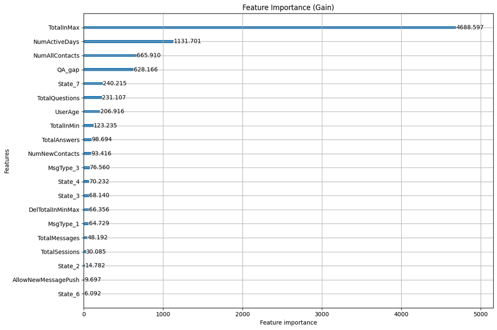

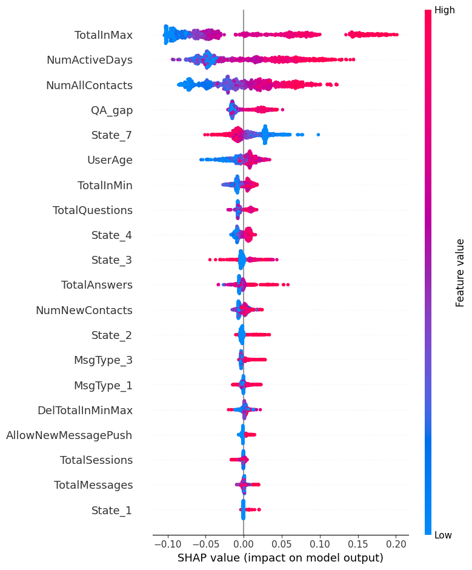

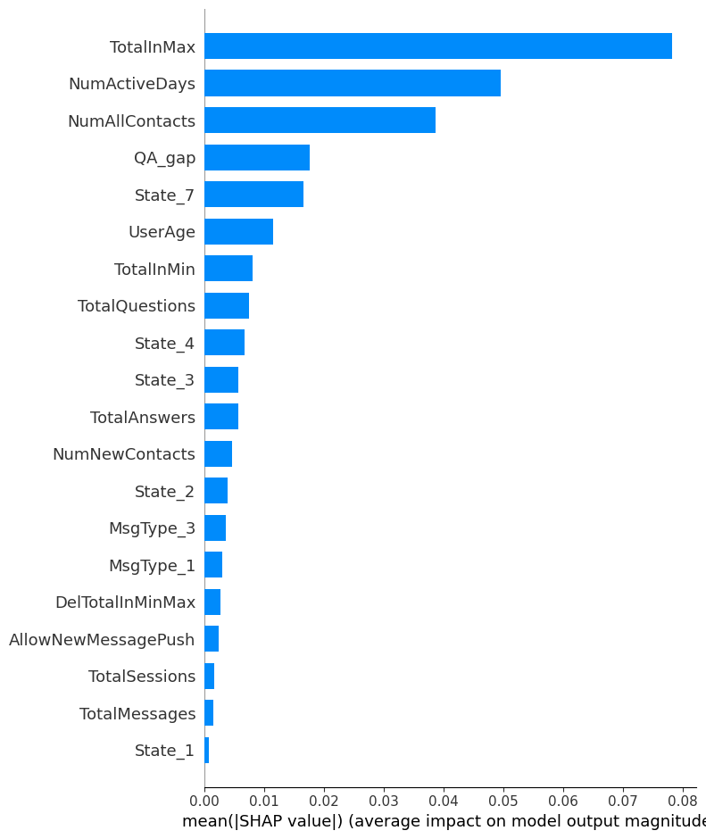

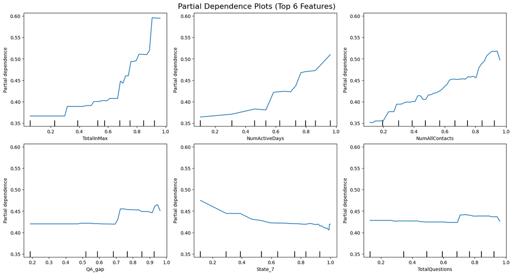

```python
# ================================
# 10. Feature Importance Plot
# ================================
lgb.plot_importance(model, max_num_features=20, importance_type="gain", figsize=(12, 8))
plt.title("Feature Importance (Gain)")
plt.tight_layout()
plt.show()

# ================================
# 11. SHAP Analysis
# ================================
explainer = shap.TreeExplainer(model)
shap_values = explainer.shap_values(X_test)

# SHAP Summary Dot Plot
shap.summary_plot(shap_values, X_test, plot_type="dot")

# SHAP Summary Bar Plot
shap.summary_plot(shap_values, X_test, plot_type="bar")

# ================================
# 12. Partial Dependence Plots (PDP)
# ================================
# top_features_names

fig, ax = plt.subplots(nrows=2, ncols=3, figsize=(15, 8), constrained_layout=True)
ax_flat = ax.flatten()
PartialDependenceDisplay.from_estimator(
    model,
    X_test,
    features=list(top_features_names[:6]),  # use first 6 features
    kind="average",
    grid_resolution=50,
    ax=ax_flat,
)
plt.suptitle("Partial Dependence Plots (Top 6 Features)", fontsize=16)
plt.show()
```

### Explanation

**SHAP (SHapley Additive exPlanations)** summary:

- Which features impact the prediction most
- How they influence it (positively or negatively).
- SHAP values show how much a feature pushes the prediction up or down.

Centered around 0:

```
➕ Right = increase prediction

➖ Left = decrease prediction
```

- Red = high feature value
- Blue = low feature value

**Partial Dependence Plots (PDP):**

Each subplot shows how changing a single feature value affects the model's average prediction, holding all other features constant.

- X-axis: feature value (normalized here between 0–1).
- Y-axis: predicted ActivityScore (partial dependence).

## Model Performance Summary

These metrics indicate a **moderate predictive performance**, with the model capturing approximately **52% of the variance** in churn behavior. The MAE shows that, on average, the prediction error is about `0.15` units.